# Omics Integration course: General Advanced Mathematical Statistics: Feature Selection

Stockholm, Sweden

Nikolay Oskolkov, SciLifeLab, NBIS Long Term Support, nikolay.oskolkov@scilifelab.se

June 14, 2018

Abstract

Here we will cover basic concepts ofunivariate and mutlivariate feature selection using LASSO, Ridge, Elastic Net and Partial Least Squares (PLS) regression models.

### Why to Select Good Features?

Imagine that we are interested in monitoring a variable Y (we will call it a Response), which can be e.g. a phenotype of interest (in biology), sell profit (in econometrics and business), reaction of a person on some action (in phycology) etc. We have collected 10 independent (or dependent) observations/samples Y1, Y2,…, Y10 of the Response and we observe some variation in the Response from sample to sample.

Now, we want to understand what this variation is due to. We need to know this in order to understand mechanisms (biological, economical etc.) behid this variation. Assume that besides the Response Y, we collected data about possible drivers/causes of Y such as gene expression (in biology), customer’s social status and income (in econometrics) etc. Suppose we collected 100 possible drivers/predictors/causes for each of Y1, Y2,…, Y10, we can represent those predictors as a matrix X with 100 columns (one for each predictor) and 10 rows (one for each observation Y1, Y2,…, Y10). We know that the variation in Y is probably due to some variables (columns/predictors) in X matrix, but do all of them equally explain the variation? Probably not, **it is reasonable to assume that only a fraction of the variables in X are causal for the variation in Y**, but which of them are causal? To answer this question we have to test the variables in X against Y, but how should we do it: test them all or one-by-one?

Here we have a typical biological case scanario when number of drivers/causes/predictors (we will call them features in the future), p=100, is much greater than the number of samples/observations, n=10, **p>>n**. This case is called “the underdetermined system” in mathematics, it does not have a unique solution but infinitely many solutions. Therefore **if we want to select features explaining the variation in the Response Y, we can not directly test all the features together without regularizations**. Therefore it makes sense to stick (at least in the beginning) to testing the features one-by-one.

Here, we are going to go through methods for a) Univariate (one-by-one) Feature Selection, and b) Multivariate (all together) Feature Selection. For practicing the concept of Feature Selection, we will use the skeletal muscle gene expression subset (randomly sampled 1000 genes) from GTEX Human Tussue Gene Expression Consortium [1]. Here we load the gene expression matrix X, remove lowly expressed genes and pre-view it:

```r
X<-read.table("GTEX_SkeletalMuscles_157Samples_1000Genes.txt",header=TRUE,row.names=1,check.names=FALSE,sep="\t")
X<-X[,colMeans(X)>=1]
X[1:5,1:3]
```

```
##                         ENSG00000243824.1_RP11-434O22.1
## GTEX-N7MS-0426-SM-2YUN6                               2
## GTEX-NFK9-0626-SM-2HMIV                               0
## GTEX-NPJ8-1626-SM-2HMIY                               0
## GTEX-O5YT-1626-SM-32PK6                               0
## GTEX-OHPM-1626-SM-2HMK4                               0
##                         ENSG00000140527.10_WDR93 ENSG00000205352.6_PRR13
## GTEX-N7MS-0426-SM-2YUN6                        2                     543
## GTEX-NFK9-0626-SM-2HMIV                        0                    1482
## GTEX-NPJ8-1626-SM-2HMIY                        3                    1958
## GTEX-O5YT-1626-SM-32PK6                        0                    1174
## GTEX-OHPM-1626-SM-2HMK4                        7                    1092
```

```r
dim(X)
```

```
## [1] 157 546
```

We can see that the gene expression data set includes p = 546 expressed genes (features) and n = 157 samples, i.e. p >> n. The phenotype of interest we are going to address is Gender, i.e. we will figure out which of the 546 genes expressed in human skeletal muscles drive the phenotypic difference between Males and Females. Thus our response Y vector is the following:

```r
Y<-read.table("GTEX_SkeletalMuscles_157Samples_Gender.txt",header=TRUE,sep="\t")$GENDER
summary(Y)
```

```
## Female   Male
##     58     99
```

```r
length(Y)
```

```
## [1] 157
```

The data set used here includes 99 Males and 58 Females, it is not perfectly balanced but still not too bad. To visualize the samples, let us display a PCA plot of the 157 samples. We will use the package `mixOmics` to do this.

```r
##Download the file "mixOmics_6.3.1.tar.gz"
##Install it in R using:
install.packages("mixOmics_6.3.1.tar.gz", repos = NULL, type="source", dependencies = TRUE)

#If you get a "missing dependencie" error, run the following:
install.packages(c("corpcor","ellipse","rgl","rARPACK","tidyr"))
```

Now we run the PCA:

```r
library("mixOmics")
pca.gtex <- pca(X, ncomp=10)
pca.gtex
```

```
## Eigenvalues for the first 10 principal components, see object$sdev^2:
##         PC1         PC2         PC3         PC4         PC5         PC6
## 11979554198  1922793376   470907790   173035873    83960716    38937526
##         PC7         PC8         PC9        PC10
##    29568540    24951919    19376723    17467325
##
## Proportion of explained variance for the first 10 principal components, see object$explained_variance:
##         PC1         PC2         PC3         PC4         PC5         PC6
## 0.804731856 0.129164496 0.031633439 0.011623761 0.005640098 0.002615646
##         PC7         PC8         PC9        PC10
## 0.001986280 0.001676156 0.001301640 0.001173375
##
## Cumulative proportion explained variance for the first 10 principal components, see object$cum.var:
##       PC1       PC2       PC3       PC4       PC5       PC6       PC7
## 0.8047319 0.9338964 0.9655298 0.9771536 0.9827937 0.9854093 0.9873956
##       PC8       PC9      PC10
## 0.9890717 0.9903734 0.9915467
##
##  Other available components:
##  --------------------
##  loading vectors: see object$rotation
```

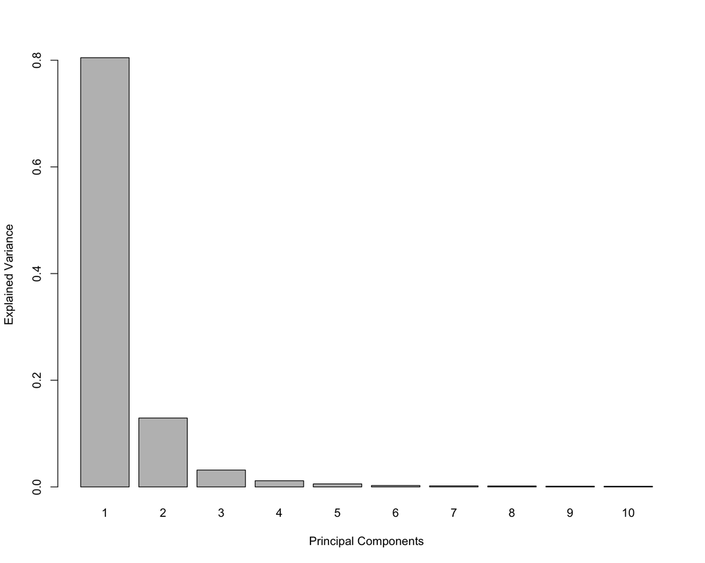

```r
plot(pca.gtex)
```

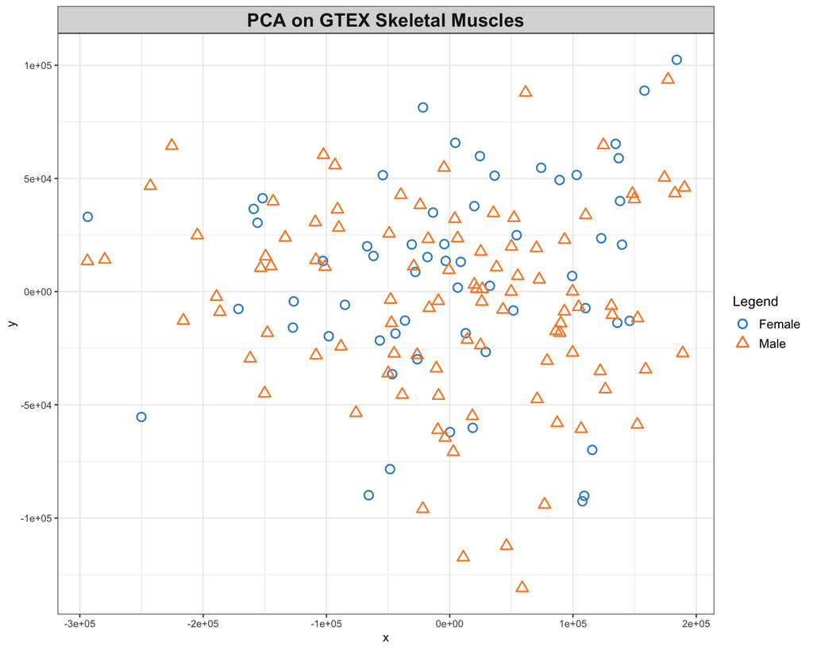

```r
plotIndiv(pca.gtex, group = Y, ind.names = FALSE, legend = TRUE, title = 'PCA on GTEX Skeletal Muscles')
```

The PCA plot demonstrates that there is a lot of variation between samples with respect to both PC1 and PC2, but there is no clear seggregation of Males and Females based on their skeletal muscle gene expression data. Now we are going to start with a simple gene-by-gene univariate feature selection and extend it to a multivariate features selection with different methods.

### Univariate Feature Selection

One way to understand what genes stand behind the variation between (Males and Females) samples would be to test correlation of each individual feature (gene) against the phenotype of interest (Gender), in our case this is equivalent to a simple Differential Gene Expression (DGE) analysis. Here we will use a simple non-parametric Spearman correlation for inferring relation between X and Y, one can alternatively use other measures of relatedness like Mann-Whittney test (wilcox.test function in base R), Linear Regression (lm function in base R), Distance Correlations (dcor function in “energy” R package), Maximal Information Coefficient (MIC) (mine function in “minerva” R package) etc.

```r
rho<-vector()
p<-vector()
a<-seq(from=0,to=dim(X)[2],by=100)
for(i in 1:dim(X)[2])
{
  corr_output<-cor.test(X[,i],as.numeric(Y),method="spearman")
  rho<-append(rho,as.numeric(corr_output$estimate))
  p<-append(p,as.numeric(corr_output$p.value))
  if(isTRUE(i%in%a)==TRUE){print(paste("FINISHED ",i," FEATURES",sep=""))}
}
```

```
## [1] "FINISHED 100 FEATURES"
## [1] "FINISHED 200 FEATURES"
## [1] "FINISHED 300 FEATURES"
## [1] "FINISHED 400 FEATURES"
## [1] "FINISHED 500 FEATURES"
```

```r
output<-data.frame(GENE=colnames(X), SPEARMAN_RHO=rho, PVALUE=p)
output$FDR<-p.adjust(output$PVALUE,method="BH")
output<-output[order(output$FDR,output$PVALUE,-output$SPEARMAN_RHO),]
head(output,10)
```

```
##                             GENE SPEARMAN_RHO       PVALUE          FDR
## 256    ENSG00000184368.11_MAP7D2   -0.5730196 4.425151e-15 2.416132e-12
## 324       ENSG00000110013.8_SIAE    0.3403994 1.288217e-05 3.516833e-03
## 297    ENSG00000128487.12_SPECC1   -0.3003621 1.323259e-04 2.408332e-02
## 218      ENSG00000162512.11_SDC3    0.2945390 1.807649e-04 2.467441e-02
## 38     ENSG00000129007.10_CALML4    0.2879754 2.549127e-04 2.783647e-02
## 107   ENSG00000233429.5_HOTAIRM1   -0.2768054 4.489930e-04 4.085836e-02
## 278    ENSG00000185442.8_FAM174B   -0.2376098 2.731100e-03 2.130258e-01
## 421     ENSG00000234585.2_CCT6P3   -0.2322268 3.426233e-03 2.338404e-01
## 371       ENSG00000113312.6_TTC1    0.2284351 4.007655e-03 2.431310e-01
## 269 ENSG00000226329.2_AC005682.6   -0.2226587 5.064766e-03 2.523944e-01
```

We have ranked all genes by their contribution to the variation in skeletal muscles gene expression between Males and Females. The ranking is based on Spearman correlation p-value which was adjusted (FDR column) to acount for the effect of multiple independent statistical tests.

Now there is a temptation to take the top differentially expressed genes with e.g. FDR < 0.05 and build a prediction score that can be used for descriminating Males and Females based on skeletal muscle gene expression in any other cohort. Why do we need that kind of prediction score? Suppose the phenotype of interest is a disease status (Sick-Healthy), then this prediction is of a major need and importance for clinical diagnostics in e.g. cancer and diabetes.

However, in practice this type of prediction based on Univariate Feature Selection works very poorly. The reason is that the Univariate Feature Selection has at least two severe problems which we have not addressed yet.

- Univariate Feature Selection does not fully overcome the p >> n obstacle (FDR correction is not enough), i.e. it is prone to overfitting and has a poor generalization.
- Univariate Feature Selection does not account for multi-collinearity between features, i.e. when different features are strongly related/correlated with each other.

The shortcomings mentioned above can be addressed with Sparse Linear Models, i.e. models with regularization penalties like LASSO, Ridge and Elastic Net which are basic techniques for Multivariate Feature Selection.

### Multivariate Feature Selection: LASSO, Ridge, Elastic Net

The simplest way to account for all explanatory variables (genes) in X simultaneously would be to put them all into the the multiple/multivariate linear regression model and perform Ordinary Least Squares minimization:

$$Y = \beta_1X_1+\beta_2X_2+\epsilon$$
$$\textrm{OLS} = (y-\beta_1X_1-\beta_2X_2)^2$$

Here for simplicity we used only two predictors X1 and X2, but there can be thousands and millions of them. It implies that in order to minimize the OLS cost function we have to do it in highly-dimensional spaces which is inherently difficult because of the “curse of dimensionality”. This leads to a very unstable sulution of multiple linear reression. To vercome this obstacle we can add a penalty term to the OLS cost function:

$$\textrm{Penalized OLS} = (y-\beta_1X_1-\beta_2X_2)^2 + \lambda[\alpha(|\beta_1|+|\beta_2|)+(1-\alpha)(\beta_1^2+\beta_2^2)]$$

Here, $\lambda$ is called Lagrange multiplier and is a measure of how much penalty we would like to put on our Linear Regression Model, its optimal value is usually found through K-fold cross-validation. The parameter $\alpha$ is usually fixed (but in principle can also be found through cross-validation) and the regularization is called 1) LASSO if $\alpha=1$, 2) Ridge if $\alpha=0$, and 3) Elastic Net if $\alpha=0.5$. These penalty methods have a few differences which are good to remember when you select a method for your analysis. LASSO is the most strict penalty and works best at the data with lots of noise. A problem of LASSO is that it can not fully handle multi-collinearity among predictors. If two variables are strongly correlated, LASSO will select only one of them (by chance) and set the coefficient in front of the other one to zero. Sometimes this type of selection can be problematic if it happens that the feature that was ignored/omitted has more physical/biological interpretation/meaning than the one which was selected by LASSO. This situation can be avoided with Ridge penalty, in addition Ridge is much more stable for numerical minimization as it provides a fully convex manifold in a multi-dimensional space. However, in ultra-higly-dimensional spaces Ridge can be too allowing and provide too many “noisy” features which might not be very interesting. Elastic Net penalty provides a compromise between LASSO and Ridge and is generally prefered and recommended by Machine Learning practicioners.

In the example below we will run LASSO penalty on Y vs. X Linear Model and find an optimal value of $\lambda$ via 10-fold cross-validation:

```r
library("glmnet")
```

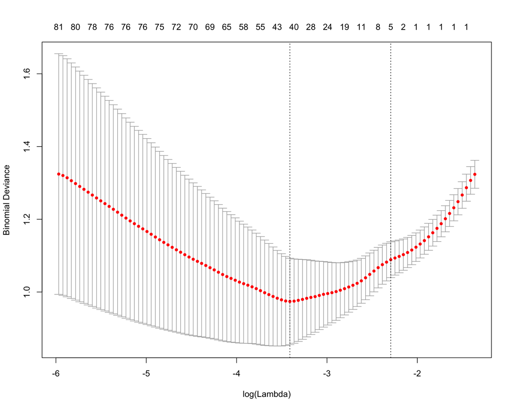

```r
lasso_fit <- cv.glmnet(as.matrix(X), Y, family="binomial", alpha=1)
plot(lasso_fit)
```

```r
lasso_fit$lambda.min
```

```
## [1] 0.0330225
```

```r
log(lasso_fit$lambda.min)
```

```
## [1] -3.410566
```

Once we know the optimal $\lambda$, we can display the names of the most informative features selected by LASSO for that optimal $\lambda$.

```r
coef<-predict(lasso_fit, s = "lambda.min", type = "nonzero")
colnames(X)[unlist(coef)]
```

```
##  [1] "ENSG00000183808.7_RBM12B"         "ENSG00000129007.10_CALML4"
##  [3] "ENSG00000244306.5_CTD-2314B22.3"  "ENSG00000135541.16_AHI1"
##  [5] "ENSG00000151023.12_ENKUR"         "ENSG00000257647.1_RP11-701H24.3"
##  [7] "ENSG00000184949.10_FAM227A"       "ENSG00000261529.1_RP13-487P22.1"
##  [9] "ENSG00000234336.2_JAZF1-AS1"      "ENSG00000198954.4_KIAA1279"
## [11] "ENSG00000109943.4_CRTAM"          "ENSG00000144677.10_CTDSPL"
## [13] "ENSG00000198729.4_PPP1R14C"       "ENSG00000187239.12_FNBP1"
## [15] "ENSG00000203836.7_NBPF24"         "ENSG00000250240.1_CTD-2154I11.2"
## [17] "ENSG00000233012.2_HDAC1P2"        "ENSG00000153904.14_DDAH1"
## [19] "ENSG00000016602.8_CLCA4"          "ENSG00000136279.14_DBNL"
## [21] "ENSG00000162512.11_SDC3"          "ENSG00000124749.12_COL21A1"
## [23] "ENSG00000254510.1_RP11-867G23.10" "ENSG00000130300.4_PLVAP"
## [25] "ENSG00000184368.11_MAP7D2"        "ENSG00000267834.1_RP11-167N5.5"
## [27] "ENSG00000168566.11_SNRNP48"       "ENSG00000128487.12_SPECC1"
## [29] "ENSG00000230267.2_HERC2P4"        "ENSG00000110013.8_SIAE"
## [31] "ENSG00000113312.6_TTC1"           "ENSG00000227407.1_AC008746.3"
## [33] "ENSG00000271964.1_RP11-415F23.2"  "ENSG00000261064.1_RP11-1000B6.3"
## [35] "ENSG00000207697.1_MIR573"         "ENSG00000182742.5_HOXB4"
## [37] "ENSG00000140391.10_TSPAN3"        "ENSG00000161847.9_RAVER1"
## [39] "ENSG00000172766.14_NAA16"         "ENSG00000152766.5_ANKRD22"
```

We can see that LASSO selected 40 most informative features and set the coefficients in front of the other features to zero. Finally, let us use LASSO scoring system for ranking of selected features by their importance:

```r
result<-data.frame(GENE = names(as.matrix(coef(lasso_fit, s = "lambda.min"))[as.matrix(coef(lasso_fit, s = "lambda.min"))[,1]!=0, 1])[-1], SCORE = as.numeric(as.matrix(coef(lasso_fit, s = "lambda.min"))[as.matrix(coef(lasso_fit, s = "lambda.min"))[,1]!=0, 1])[-1])
result<-result[order(-abs(result$SCORE)),]
head(result,10)
```

```
##                                GENE       SCORE
## 23 ENSG00000254510.1_RP11-867G23.10 -0.04911597
## 25        ENSG00000184368.11_MAP7D2 -0.03238072
## 32     ENSG00000227407.1_AC008746.3 -0.02821300
## 26   ENSG00000267834.1_RP11-167N5.5 -0.02467923
## 5          ENSG00000151023.12_ENKUR  0.02316296
## 40        ENSG00000152766.5_ANKRD22 -0.02190591
## 2         ENSG00000129007.10_CALML4  0.02008264
## 1          ENSG00000183808.7_RBM12B -0.01945735
## 35         ENSG00000207697.1_MIR573 -0.01552758
## 8   ENSG00000261529.1_RP13-487P22.1 -0.01376148
```

We conclude that the features selected by Multivariate Feature Selection approach do not look quite similar to the ones selected by Univariate Feature Selection in the previous section, this is generally the case in practice and it is good to remember that the features selected in Multivariate fashion have proven to have much higher modelling/predictive capacity.

### Multivariate Feature Selection: PLS

Another elegant Multivariate Feature Selection method is Partial Least Squares (PLS) regression which is also called (by its author) Projection on Latent Structures (PLS). The idea behind PLS is very simple, it perfoms feature selection as a group via maximizing the covariance between X and Y:

$$\max_{\beta}\textrm{cov}(X,Y) \Longrightarrow \hat\beta$$

This algorithm can roughly be viewed as a process of collective selection of features that provides the largest separation in a lower dimensional space like PCA plot. The maximized covariance matrix (build on selected most informative features) can then be factorized (expanded into orthogonal components) and visualized:

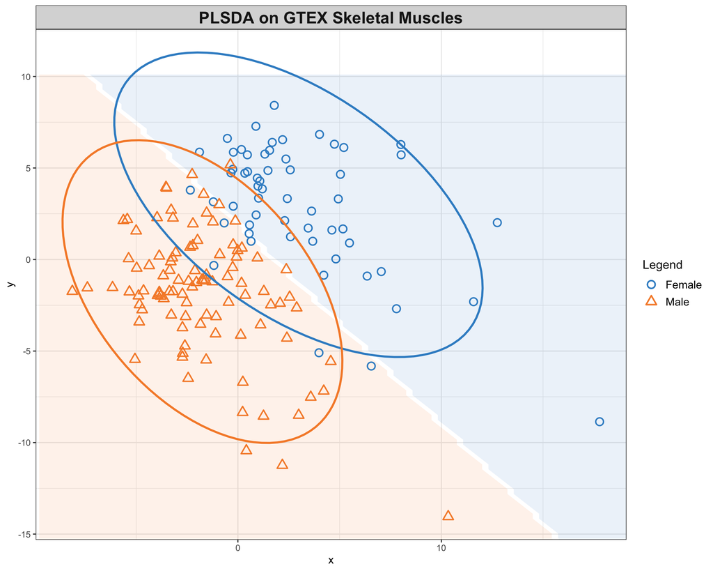

```r
library("mixOmics")
gtex.plsda <- plsda(X, Y, ncomp = 2)
background = background.predict(gtex.plsda, comp.predicted = 2, dist = "max.dist")
plotIndiv(gtex.plsda , comp = 1:2, group = Y, ind.names = FALSE, ellipse = TRUE, legend = TRUE, title = 'PLSDA on GTEX Skeletal Muscles', background = background)
```

We observe a much more clear separation between Males and Females compared to the PCA plot above. This separation is achied by selecting most informative features which can be visualized and ranked by their contribution via PLS loadings:

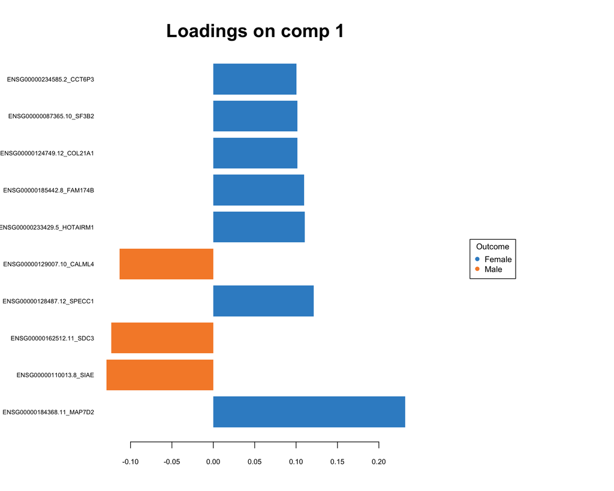

```r
plotLoadings(gtex.plsda, comp = 1, title = 'Loadings on comp 1', contrib = 'max', method = 'median', ndisplay = 10, size.name = 0.6)
```

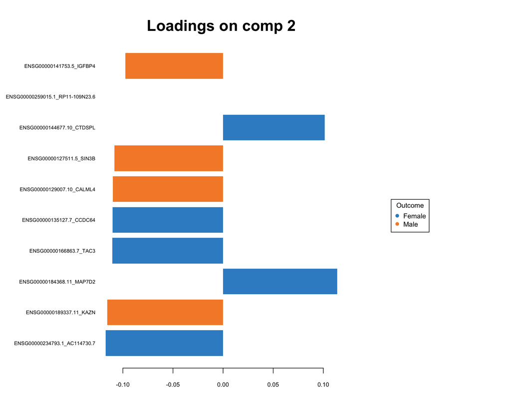

```r
plotLoadings(gtex.plsda, comp = 2, title = 'Loadings on comp 2', contrib = 'max', method = 'median', ndisplay = 10, size.name = 0.6)
```

### References

[1] The Genotype-Tissue Expression (GTEx) project. The GTEx Consortium. Nature Genetics. 29 May 2013. 45(6):580-5.